# R Notebook

# Loading in libraries

```r
library(tidyverse)
library(forcats)
library(janitor)
library(scales)
library(fable)
library(fabletools)
library(tsibble)
```

# Reading in the data and then cleaning variable names

```r
geo_codes_and_labels <- read_csv("geography_codes_and_labels_hb2014_01042019.csv") %>%
  clean_names()

cancer_incidence <- read_csv("opendata_inc9418_hb.csv") %>%
  clean_names()
```

# Exploring the data

```r
head(geo_codes_and_labels)
view(geo_codes_and_labels)

head(cancer_incidence)
summary(cancer_incidence)
```

## The data appears to be in a wider form than preferred for analysis but I’ve feel I can perform the analysis I need without formatting it too much.

# Recoding the NHS Board names to allow for easier analysis

```r
recoding_cancer_data <- cancer_incidence %>%
  mutate(hb =case_when(
    hb == "S08000015" ~ "NHS Ayrshire and Arran",
    hb == "S08000016" ~ "NHS Borders",
    hb == "S08000017" ~ "NHS Dumfries and Galloway",
    hb == "S08000029" ~ "NHS Fife",
    hb == "S08000019" ~ "NHS Forth Valley",
    hb == "S08000020" ~ "NHS Grampian",
    hb == "S08000031" ~ "NHS Greater Glasgow and Clyde",
    hb == "S08000022" ~ "NHS Highland",
    hb == "S08000032" ~ "NHS Lanarkshire",
    hb == "S08000024" ~ "NHS Lothian",
    hb == "S08000025" ~ "NHS Orkney",
    hb == "S08000026" ~ "NHS Shetland",
    hb == "S08000030" ~ "NHS Tayside",
    hb == "S08000028" ~ "NHS Western Isles",
    TRUE ~ hb))

recoding_cancer_data
```

According to the NHS website, as their is a strong link between age and risk of cancer, a high crude rate is a good indication of a high proportion of elderly people within a population. It is therefore acceptable to say crude rate values will be valuable for NHS Borders to look at when planning for provision of cancer treatment services.

# Average Crude Rates for all cancer types over 24 years period, comparison by NHS Board

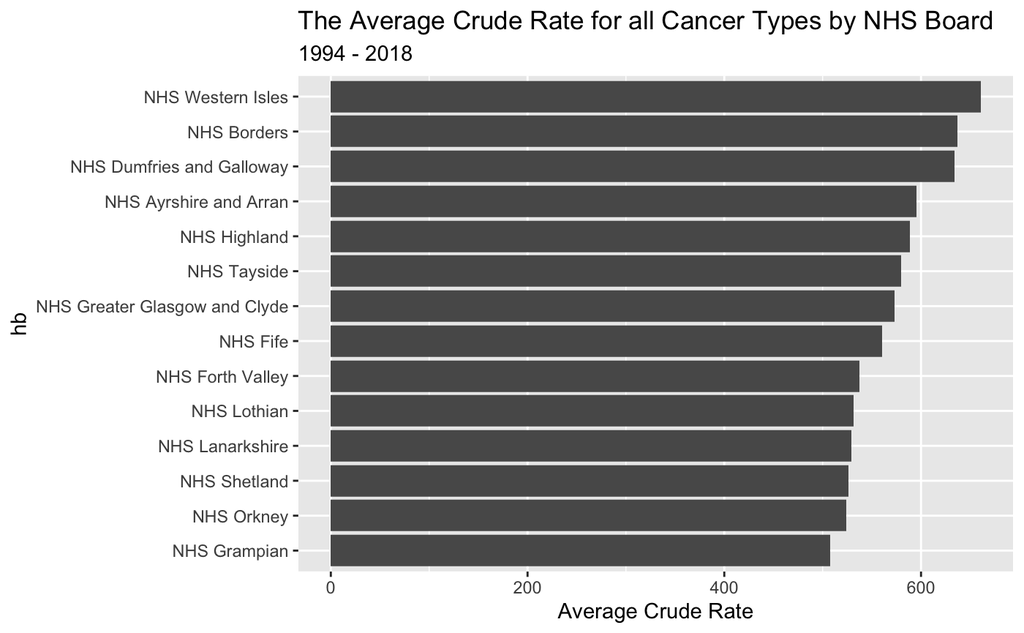

```r
crude_rate_comparison <- recoding_cancer_data %>%
  filter(sex == "All",
         cancer_site == "All cancer types") %>%
    group_by(hb) %>%
    summarise(aver_crude_rate = mean(crude_rate)) %>%
  mutate(hb = fct_reorder(hb, aver_crude_rate)) %>%
  ggplot() +
  coord_flip() +
  aes(x = hb , y = aver_crude_rate) +
  geom_bar(stat = "identity") +
  labs( y = "Average Crude Rate",
       title = "The Average Crude Rate for all Cancer Types by NHS Board",
       subtitle = "1994 - 2018")
crude_rate_comparison
```

```r
NA
```

The Borders reports the 2nd highest average crude rate over the 24 year period.

# How crude rate has varied over time for all cancer types within NHS Borders catchment area

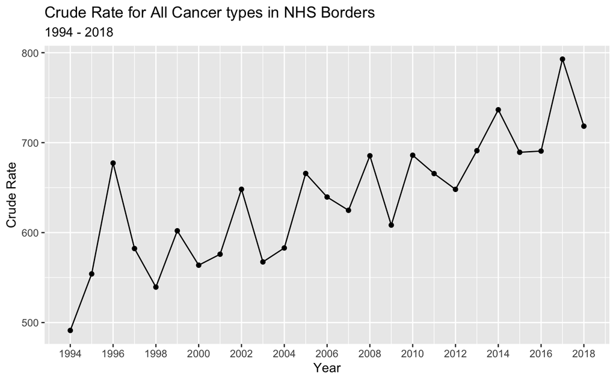

```r
cr_borders_over_time <- recoding_cancer_data %>%
  filter(sex == "All",
         cancer_site == "All cancer types", hb == 'NHS Borders') %>%
ggplot() +
  aes(x = year, y = crude_rate) +
  geom_line() +
  geom_point()+
  scale_x_continuous(breaks = breaks_extended(14))+
  labs(x = "Year",
       y = "Crude Rate",
       title = "Crude Rate for All Cancer types in NHS Borders",
       subtitle = "1994 - 2018")

cr_borders_over_time
```

Their appears to be an upwards trend of crude rate over the 24 year period.

# All recorded incidences of cancer reported in Borders by year

```r
borders_cancer_incidence <- cancer_incidence %>%
  filter(hb == "S08000016")
```

# The Number of Incidences of Cancer (all types) in NHS Borders

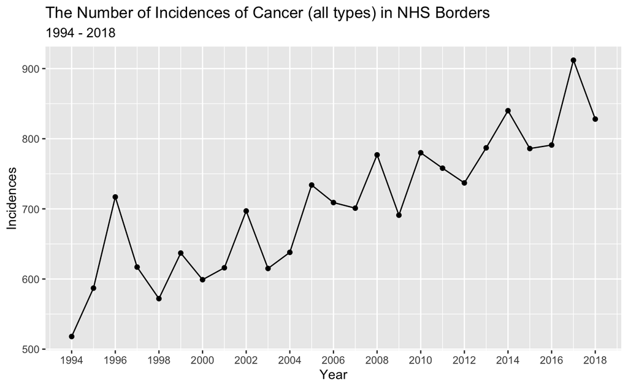

```r
all_cancer_types <- borders_cancer_incidence %>%
  filter(cancer_site == "All cancer types",
         sex == "All") %>%
  group_by(year) %>%
  summarise(incidences_all_ages) %>%
  ggplot() +
  aes(x = year, y = incidences_all_ages) +
  geom_line() +
  geom_point()+
  scale_x_continuous(breaks = breaks_extended(14))+
  labs(x = "Year",
       y = "Incidences",
       title = "The Number of Incidences of Cancer (all types) in NHS Borders",
       subtitle = "1994 - 2018")
all_cancer_types
```

# Splitting the above by sex

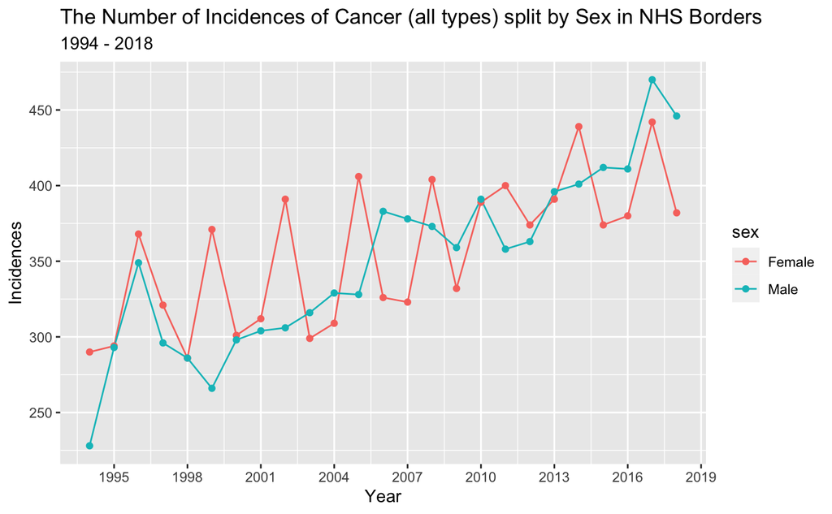

```r
all_cancer_types_by_sex <- borders_cancer_incidence %>%
  filter(cancer_site == "All cancer types",
         sex != "All") %>%
  group_by(year, sex) %>%
  summarise(incidences_all_ages) %>%
  ggplot() +
  aes(x = year, y = incidences_all_ages, colour = sex) +
  geom_line() +
  geom_point()+
  scale_x_continuous(breaks = breaks_extended(10))+
  scale_y_continuous(breaks = breaks_extended(8)) +
  labs(x = "Year",
       y = "Incidences",
       title = "The Number of Incidences of Cancer (all types) split by Sex in NHS Borders",
       subtitle = "1994 - 2018")
all_cancer_types_by_sex
```

# The top 10 cancer types in NHS Borders

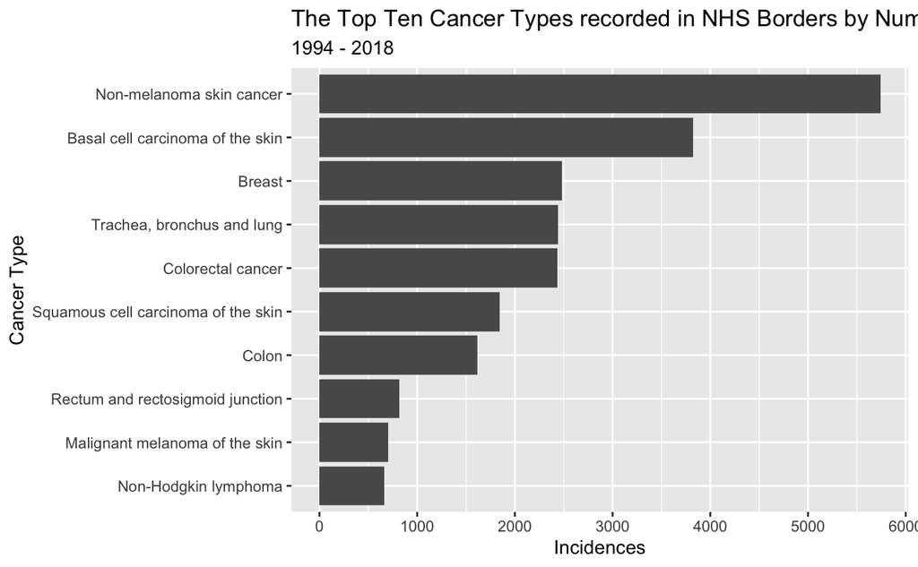

```r
top_cancer_types <- borders_cancer_incidence %>%
  filter(cancer_site != "All cancer types", sex == "All") %>%
  group_by(cancer_site) %>%
  summarise(num_incidences = sum(incidences_all_ages)) %>%
  arrange(desc(num_incidences)) %>%
  mutate(cancer_site = fct_reorder(cancer_site, num_incidences)) %>%
  head(10) %>%
  ggplot() +
  aes(x = cancer_site , y = num_incidences) +
  geom_bar(stat = "identity") +
  coord_flip()+
  scale_y_continuous(breaks = breaks_extended(8)) +
  labs(x = "Cancer Type",
       y = "Incidences",
       title = "The Top Ten Cancer Types recorded in NHS Borders by Number of Incidences",
       subtitle = "1994 - 2018")
top_cancer_types
```

# The top 5 cancer types in NHS Borders (females)

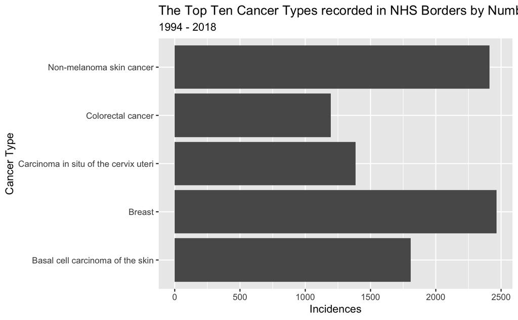

```r
top_cancer_types_sex <- borders_cancer_incidence %>%
  filter(cancer_site != "All cancer types", sex == "Female") %>%
  group_by(cancer_site, sex) %>%
  summarise(num_incidences = sum(incidences_all_ages)) %>%
  arrange(desc(num_incidences)) %>%
  mutate(cancer_site = fct_reorder(cancer_site, num_incidences)) %>%
  head(5) %>%
  ggplot() +
  coord_flip() +
  aes(x = cancer_site , y = num_incidences) +
  geom_bar(stat = "identity", position = "dodge") +
  scale_y_continuous(breaks = breaks_extended(8)) +
  labs(x = "Cancer Type",
       y = "Incidences",
       title = "The Top Ten Cancer Types recorded in NHS Borders by Number of Incidences",
       subtitle = "1994 - 2018")
top_cancer_types_sex
```